# Google Data Analytics Capstone Project

Case Study 1: How Does a Bike-Share Navigate Speedy Success?

## Scenario

You work as a junior data analyst in the marketing analyst team of **Cyclistic**, a Chicago-based bike-share firm. The company’s future prosperity, according to the director of marketing, hinges on increasing the number of yearly subscribers. As a result, your team is interested in learning how casual riders and annual members use Cyclistic bikes. As a result of these findings,

Your group will devise a new marketing approach to convert casual riders into annual subscribers. However, Cyclistic executives must first be addressed. Your recommendations must be backed up by **compelling data insights and professional data visualizations** in order for them to be approved.

## Business Tasks

- How do annual members and casual riders use Cyclistic bikes differently?
- Why would a non-cyclist purchase a Cyclistic annual membership?
- Design marketing strategies aimed at converting casual riders into annual members.
- what impact digital media might have on their marketing strategies

## Data Source

- Divvy Data

### Setting up my environment

- Importing library `tidyverse` and loading datasets

```r
library(tidyverse)
```

### Loading Data sets

```r
tripdata_202004 <- read_csv("202004-divvy-tripdata.csv")
tripdata_202005 <- read_csv("202005-divvy-tripdata.csv")
tripdata_202006 <- read_csv("202006-divvy-tripdata.csv")
tripdata_202007 <- read_csv("202007-divvy-tripdata.csv")
tripdata_202008 <- read_csv("202008-divvy-tripdata.csv")
tripdata_202009 <- read_csv("202009-divvy-tripdata.csv")
tripdata_202010 <- read_csv("202010-divvy-tripdata.csv")
tripdata_202011 <- read_csv("202011-divvy-tripdata.csv")
tripdata_202012 <- read_csv("202012-divvy-tripdata.csv")
tripdata_202101 <- read_csv("202101-divvy-tripdata.csv")
tripdata_202102 <- read_csv("202102-divvy-tripdata.csv")
tripdata_202103 <- read_csv("202103-divvy-tripdata.csv")
tripdata_202104 <- read_csv("202104-divvy-tripdata.csv")
tripdata_202105 <- read_csv("202105-divvy-tripdata.csv")
```

### `Combining all the data together`

```r
tripdata <- rbind(tripdata_202004,
                  tripdata_202005,
                  tripdata_202006,
                  tripdata_202007,
                  tripdata_202008,
                  tripdata_202009,
                  tripdata_202010,
                  tripdata_202011,
                  tripdata_202012,
                  tripdata_202101,
                  tripdata_202102,
                  tripdata_202103,
                  tripdata_202104,
                  tripdata_202105)
```

### `view the data`

```r
glimpse(tripdata)
```

```
Rows: 4,358,611
Columns: 13
$ ride_id            <chr> "A847FADBBC638E45", "5405B80E996FF60D", "5DD24A79A4E006F4", "2A59BBDF5~
$ rideable_type      <chr> "docked_bike", "docked_bike", "docked_bike", "docked_bike", "docked_bi~
$ started_at         <dttm> 2020-04-26 17:45:14, 2020-04-17 17:08:54, 2020-04-01 17:54:13, 2020-0~
$ ended_at           <dttm> 2020-04-26 18:12:03, 2020-04-17 17:17:03, 2020-04-01 18:08:36, 2020-0~
$ start_station_name <chr> "Eckhart Park", "Drake Ave & Fullerton Ave", "McClurg Ct & Erie St", "~
$ start_station_id   <chr> "86", "503", "142", "216", "125", "173", "35", "434", "627", "377", "5~
$ end_station_name   <chr> "Lincoln Ave & Diversey Pkwy", "Kosciuszko Park", "Indiana Ave & Roose~
$ end_station_id     <chr> "152", "499", "255", "657", "323", "35", "635", "382", "359", "508", "~
$ start_lat          <dbl> 41.8964, 41.9244, 41.8945, 41.9030, 41.8902, 41.8969, 41.8923, 41.8665~
$ start_lng          <dbl> -87.6610, -87.7154, -87.6179, -87.6975, -87.6262, -87.6217, -87.6120, ~
$ end_lat            <dbl> 41.9322, 41.9306, 41.8679, 41.8992, 41.9695, 41.8923, 41.8957, 41.8747~
$ end_lng            <dbl> -87.6586, -87.7238, -87.6230, -87.6722, -87.6547, -87.6120, -87.6201, ~
$ member_casual      <chr> "member", "member", "member", "member", "casual", "member", "member", ~
```

## Data Exploration

```r
table(is.na(tripdata))
```

```
   FALSE     TRUE
55786772   875171
```

### Columns with missing values

```r
colSums(is.na(tripdata))
```

```
           ride_id      rideable_type         started_at           ended_at start_station_name
                 0                  0                  0                  0             201975
  start_station_id   end_station_name     end_station_id          start_lat          start_lng
            202601             229610             230071                  0                  0
           end_lat            end_lng      member_casual
              5457               5457                  0
```

### Missing data would be removed.

```r
tripdata_cleaned <- tripdata[complete.cases(tripdata), ]
```

### checking the data again

```r
colSums(is.na(tripdata_cleaned))
```

```
           ride_id      rideable_type         started_at           ended_at start_station_name
                 0                  0                  0                  0                  0
  start_station_id   end_station_name     end_station_id          start_lat          start_lng
                 0                  0                  0                  0                  0
           end_lat            end_lng      member_casual
                 0                  0                  0
```

### Data with a “started at” value greater than “ended at” will be removed.

```r
tripdata_cleaned <- tripdata_cleaned %>%
  filter(tripdata_cleaned$started_at < tripdata_cleaned$ended_at)
```

```r
glimpse(tripdata_cleaned)
```

```
Rows: 4,033,125
Columns: 13
$ ride_id            <chr> "A847FADBBC638E45", "5405B80E996FF60D", "5DD24A79A4E006F4", "2A59BBDF5~
$ rideable_type      <chr> "docked_bike", "docked_bike", "docked_bike", "docked_bike", "docked_bi~
$ started_at         <dttm> 2020-04-26 17:45:14, 2020-04-17 17:08:54, 2020-04-01 17:54:13, 2020-0~
$ ended_at           <dttm> 2020-04-26 18:12:03, 2020-04-17 17:17:03, 2020-04-01 18:08:36, 2020-0~
$ start_station_name <chr> "Eckhart Park", "Drake Ave & Fullerton Ave", "McClurg Ct & Erie St", "~
$ start_station_id   <chr> "86", "503", "142", "216", "125", "173", "35", "434", "627", "377", "5~
$ end_station_name   <chr> "Lincoln Ave & Diversey Pkwy", "Kosciuszko Park", "Indiana Ave & Roose~
$ end_station_id     <chr> "152", "499", "255", "657", "323", "35", "635", "382", "359", "508", "~
$ start_lat          <dbl> 41.8964, 41.9244, 41.8945, 41.9030, 41.8902, 41.8969, 41.8923, 41.8665~
$ start_lng          <dbl> -87.6610, -87.7154, -87.6179, -87.6975, -87.6262, -87.6217, -87.6120, ~
$ end_lat            <dbl> 41.9322, 41.9306, 41.8679, 41.8992, 41.9695, 41.8923, 41.8957, 41.8747~
$ end_lng            <dbl> -87.6586, -87.7238, -87.6230, -87.6722, -87.6547, -87.6120, -87.6201, ~
$ member_casual      <chr> "member", "member", "member", "member", "casual", "member", "member", ~
```

- *Create a column called `ride_length` Calculate the length of each ride by subtracting the column `started_at` from the column `ended_at`*

```r
tripdata_cleaned$ride_length <- tripdata_cleaned$ended_at - tripdata_cleaned$started_at

head(tripdata_cleaned$ride_length, 20)
```

```
Time differences in secs
 [1] 1609  489  863  732 3175  324  313 4549  344 1039 1452  293  498  274 1441 2131 1302  493  955
[20]  354
```

### Import lubridate library

```r
library(lubridate)
```

*Since they are in numeric term we have to convert it.*

```r
tripdata_cleaned$ride_length <- hms::hms(seconds_to_period(tripdata_cleaned$ride_length))
head(tripdata_cleaned$ride_length)
```

```
00:26:49
00:08:09
00:14:23
00:12:12
00:52:55
00:05:24
```

### Create a column called “day_of_week,” and calculate the day of the week that each ride started

- wday(x, label = FALSE, abbr = TRUE, ordered = FALSE)

```r
tripdata_cleaned <- tripdata_cleaned %>% mutate(day_of_week = wday(started_at, label = F))
```

```r
head(tripdata_cleaned)
```

| ride_id | rideable_type | started_at | ended_at | start_station_name | start_station_id | end_station_name | end_station_id | start_lat | start_lng | end_lat | end_lng | member_casual | ride_length | day_of_week |
| --- | --- | --- | --- | --- | --- | --- | --- | --- | --- | --- | --- | --- | --- | --- |
| A847FADBBC638E45 | docked_bike | 2020-04-26 17:45:14 | 2020-04-26 18:12:03 | Eckhart Park | 86 | Lincoln Ave & Diversey Pkwy | 152 | 41.8964 | -87.6610 | 41.9322 | -87.6586 | member | 00:26:49 | 1 |
| 5405B80E996FF60D | docked_bike | 2020-04-17 17:08:54 | 2020-04-17 17:17:03 | Drake Ave & Fullerton Ave | 503 | Kosciuszko Park | 499 | 41.9244 | -87.7154 | 41.9306 | -87.7238 | member | 00:08:09 | 6 |
| 5DD24A79A4E006F4 | docked_bike | 2020-04-01 17:54:13 | 2020-04-01 18:08:36 | McClurg Ct & Erie St | 142 | Indiana Ave & Roosevelt Rd | 255 | 41.8945 | -87.6179 | 41.8679 | -87.6230 | member | 00:14:23 | 4 |
| 2A59BBDF5CDBA725 | docked_bike | 2020-04-07 12:50:19 | 2020-04-07 13:02:31 | California Ave & Division St | 216 | Wood St & Augusta Blvd | 657 | 41.9030 | -87.6975 | 41.8992 | -87.6722 | member | 00:12:12 | 3 |
| 27AD306C119C6158 | docked_bike | 2020-04-18 10:22:59 | 2020-04-18 11:15:54 | Rush St & Hubbard St | 125 | Sheridan Rd & Lawrence Ave | 323 | 41.8902 | -87.6262 | 41.9695 | -87.6547 | casual | 00:52:55 | 7 |
| 356216E875132F61 | docked_bike | 2020-04-30 17:55:47 | 2020-04-30 18:01:11 | Mies van der Rohe Way & Chicago Ave | 173 | Streeter Dr & Grand Ave | 35 | 41.8969 | -87.6217 | 41.8923 | -87.6120 | member | 00:05:24 | 5 |

## Calculation

- Calculate the mean of ride_length
- Calculate the max ride_length
- Calculate the mode of day_of_week

```r
library(DescTools)
```

```r
tripdata_summary <- tripdata_cleaned %>% summarise(ride_length_mean = mean(ride_length), ride_length_max = max(ride_length), mode_day_of_week = Mode(day_of_week))

tripdata_summary
```

| ride_length_mean | ride_length_max | mode_day_of_week |
| --- | --- | --- |
| 1654.869 secs | 3523202 secs | 7 |

- Calculate the average ride_length for members and casual riders, group by `member_casual`

```r
average_ride_length <- tripdata_cleaned %>% group_by(member_casual) %>% summarise(average_ride_length = mean(ride_length))

average_ride_length
```

| member_casual | average_ride_length |
| --- | --- |
| casual | 2652.3596 secs |
| member | 938.9665 secs |

- Calculate the average ride_length for users by day_of_week. group by `day_of_week`

```r
avg_ride_length <- tripdata_cleaned %>% group_by(day_of_week) %>% summarise(avg_ride_length = mean(ride_length))

avg_ride_length
```

| day_of_week | avg_ride_length |
| --- | --- |
| 1 | 2064.147 secs |
| 2 | 1538.681 secs |
| 3 | 1402.635 secs |
| 4 | 1397.767 secs |
| 5 | 1450.453 secs |
| 6 | 1579.200 secs |
| 7 | 1926.302 secs |

- Calculate the number of rides for users by day_of_week

```r
count_rides <- tripdata_cleaned %>% group_by(day_of_week) %>% summarise(number_rides = n())

count_rides
```

| day_of_week | number_rides |
| --- | --- |
| 1 | 635599 |
| 2 | 497245 |
| 3 | 494317 |
| 4 | 522219 |
| 5 | 523978 |
| 6 | 591740 |
| 7 | 768027 |

```r
tripdata_cleaned %>% select(ride_length,member_casual,day_of_week) %>% group_by(day_of_week,member_casual) %>% summarise(mean = mean(ride_length))
```

| day_of_week | member_casual | mean |
| --- | --- | --- |
| 1 | casual | 3002.9704 secs |
| 1 | member | 1070.9664 secs |
| 2 | casual | 2628.8342 secs |
| 2 | member | 892.2655 secs |
| 3 | casual | 2402.9326 secs |
| 3 | member | 882.3849 secs |
| 4 | casual | 2391.8368 secs |
| 4 | member | 885.4061 secs |
| 5 | casual | 2489.3593 secs |
| 5 | member | 882.7463 secs |

[output cut: 4 more lines]

```r
trip <- tripdata_cleaned %>% mutate(weekday = wday(started_at, label = T)) %>% group_by(member_casual, weekday) %>% summarise(number_of_rides = n(), average_duration = mean(ride_length)) %>% arrange(member_casual,weekday)
trip
```

| member_casual | weekday | number_of_rides | average_duration |
| --- | --- | --- | --- |
| casual | Sun | 326741 | 3002.9704 secs |
| casual | Mon | 185093 | 2628.8342 secs |
| casual | Tue | 169129 | 2402.9326 secs |
| casual | Wed | 177615 | 2391.8368 secs |
| casual | Thu | 185151 | 2489.3593 secs |
| casual | Fri | 241185 | 2546.9083 secs |
| casual | Sat | 400235 | 2736.9760 secs |
| member | Sun | 308858 | 1070.9664 secs |
| member | Mon | 312152 | 892.2655 secs |
| member | Tue | 325188 | 882.3849 secs |

[output cut: 4 more lines]

## Visualizing number of rides by type

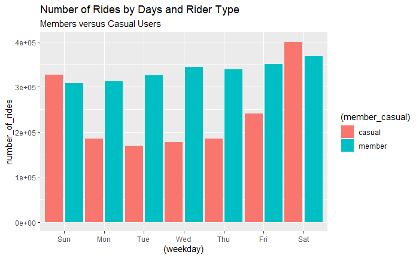

```r
ggplot(data = trip) + aes( x = (weekday), y = number_of_rides, fill = (member_casual))+geom_bar(stat='identity', position = position_dodge(width = 1))+ scale_y_continuous(labels = scales::comma) %>%  labs(title = "Number of Rides by Days and Rider Type",
       subtitle = "Members versus Casual Users")
```

*Saturday has the highest number of rides for both casual riders and members*

## Average Duration

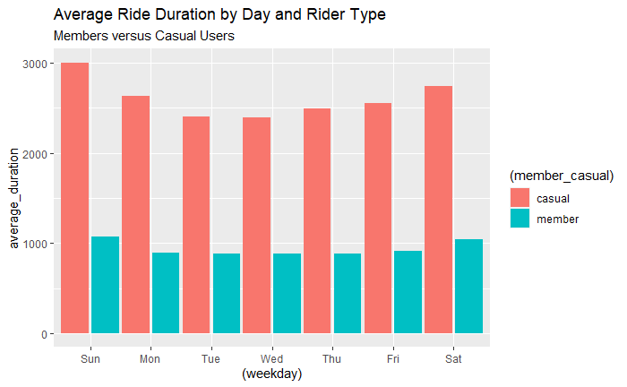

```r
ggplot(data = trip) + aes( x = (weekday), y = average_duration, fill = (member_casual))+geom_bar(stat='identity', position = position_dodge(width = 1))+ scale_y_continuous(labels = scales::comma) %>%  labs(title = "Average Ride Duration by Day and Rider Type",
       subtitle = "Members versus Casual Users")
```

*This shows that casual riders prefer longer rides*

```r
trip_add <- tripdata_cleaned %>% group_by(member_casual,rideable_type) %>% summarise(number_of_rides = n(), average_duration = mean(ride_length)) %>% arrange(member_casual,rideable_type)
trip_add
```

| member_casual | rideable_type | number_of_rides | average_duration |
| --- | --- | --- | --- |
| casual | classic_bike | 264398 | 1732.6565 secs |
| casual | docked_bike | 1179423 | 3139.2790 secs |
| casual | electric_bike | 241328 | 1280.3002 secs |
| member | classic_bike | 576650 | 842.1474 secs |
| member | docked_bike | 1432357 | 1014.2990 secs |
| member | electric_bike | 338969 | 785.3464 secs |

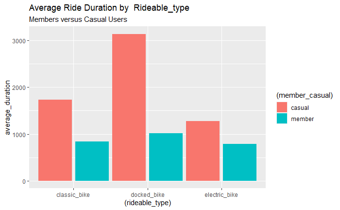

```r
ggplot(data = trip_add) + aes( x = (rideable_type), y = average_duration, fill = (member_casual))+geom_bar(stat='identity', position = position_dodge(width = 1))+ scale_y_continuous(labels = scales::comma) %>%  labs(title = "Average Ride Duration by  Rideable_type",
       subtitle = "Members versus Casual Users")
```

*The most popular mode of transportation among riders is docked bicycles.*

```r
trip_month <- tripdata_cleaned %>% mutate(month = month(started_at, label = T)) %>% group_by(member_casual, month) %>% summarise(number_of_rides = n(), average_duration = mean(ride_length)) %>% arrange(member_casual,month)
trip_month
```

| member_casual | month | number_of_rides | average_duration |
| --- | --- | --- | --- |
| casual | Jan | 14690 | 1582.2002 secs |
| casual | Feb | 8613 | 2828.2271 secs |
| casual | Mar | 75641 | 2308.8290 secs |
| casual | Apr | 143984 | 2640.9932 secs |
| casual | May | 303516 | 2566.1935 secs |
| casual | Jun | 154329 | 3073.9902 secs |
| casual | Jul | 268103 | 3557.3681 secs |
| casual | Aug | 281945 | 2655.0364 secs |
| casual | Sep | 214672 | 2305.2920 secs |
| casual | Oct | 122317 | 1877.9625 secs |

[output cut: 14 more lines]

```r
NA
```

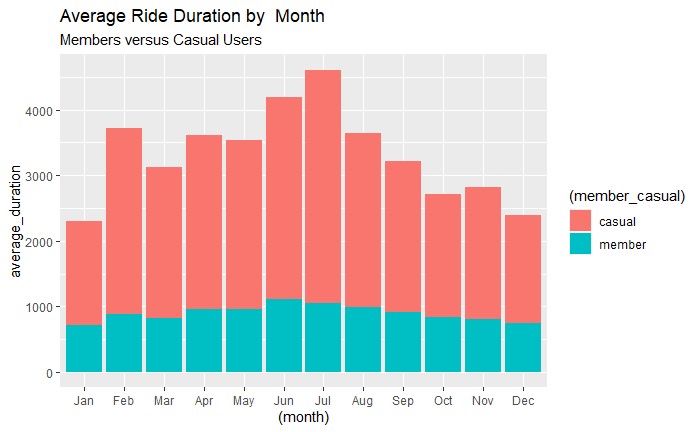

```r
ggplot(data = trip_month) + aes( x = (month), y = average_duration, fill = (member_casual))+geom_bar(stat='identity')+ scale_y_continuous(labels = scales::comma) %>%  labs(title = "Average Ride Duration by  Month",
       subtitle = "Members versus Casual Users")
```

*The longest riders are most active in July.*

```r
trip_ride <- tripdata_cleaned %>%  mutate(weekday = wday(started_at, label = T)) %>% group_by(member_casual, weekday) %>% summarise(number_of_rides = n()) %>% arrange(member_casual, weekday)
trip_ride
```

| member_casual | weekday | number_of_rides |
| --- | --- | --- |
| casual | Sun | 326741 |
| casual | Mon | 185093 |
| casual | Tue | 169129 |
| casual | Wed | 177615 |
| casual | Thu | 185151 |
| casual | Fri | 241185 |
| casual | Sat | 400235 |
| member | Sun | 308858 |
| member | Mon | 312152 |
| member | Tue | 325188 |

[output cut: 4 more lines]

```r
NA
```

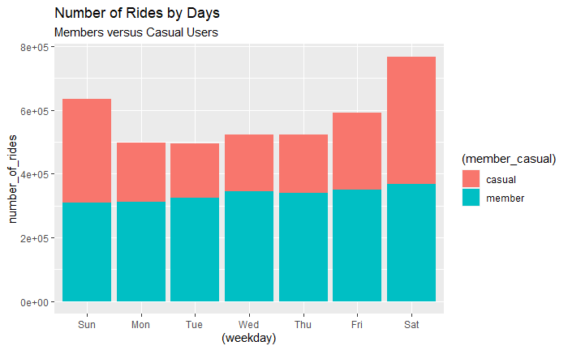

*I propose starting a marketing campaign in June to encourage casual riders to our Docked Bikes service on weekends, particularly Saturdays.*

```r
trip_station <- tripdata_cleaned %>%  group_by(member_casual,start_station_name ) %>% summarise(number_of_rides = n(), average_duration = mean(ride_length)) %>% arrange(member_casual,start_station_name) %>%  arrange(desc(number_of_rides,average_duration))
trip_station
```

| member_casual | start_station_name | number_of_rides | average_duration |
| --- | --- | --- | --- |
| casual | Streeter Dr & Grand Ave | 36471 | 3037.240410 secs |
| casual | Lake Shore Dr & Monroe St | 28000 | 3167.078857 secs |
| casual | Millennium Park | 25240 | 4368.801387 secs |
| member | Clark St & Elm St | 23885 | 823.850827 secs |
| member | Wells St & Concord Ln | 18484 | 799.168903 secs |
| casual | Theater on the Lake | 18362 | 2402.874578 secs |
| casual | Michigan Ave & Oak St | 18351 | 3180.924364 secs |
| member | Broadway & Barry Ave | 18319 | 902.704569 secs |
| member | Dearborn St & Erie St | 18152 | 809.502369 secs |
| member | St. Clair St & Erie St | 18116 | 941.924100 secs |

[output cut: 990 more lines]

```r
NA
```

We should also pay attention to these stations

- Streeter Sr & Grand Ave
- Lake Shore Dr & Monroe St
- Millenium Park.